# Chapter 11, Vignette 1: Background on the F distribution

Dev P. Chakraborty, PhD

2020-01-07

## Introduction

Since it plays an important role in sample size estimation, it is helpful to examine the behavior of the F-distribution. In the following `ndf` = numerator degrees of freedom, `ddf` = denominator degrees of freedom and `ncp` = non-centrality parameter (i.e., the $\Delta$ appearing in Eqn. (11.6) of (Chakraborty 2017)).

The use of three `R` functions is demonstrated.

## Effect of `ncp` for `ndf` = 2 and `ddf` = 10

- Four values of `ncp` are considered (0, 2, 5, 10) for `ddf` = 10.
- `fCrit` is the critical value of the F distribution, i.e., that value such that fraction $\alpha$ of the area is to the right of the critical value, i.e., `fCrit` is identical in statistical notation to ${{F}_{1-\alpha ,ndf,ddf}}$.

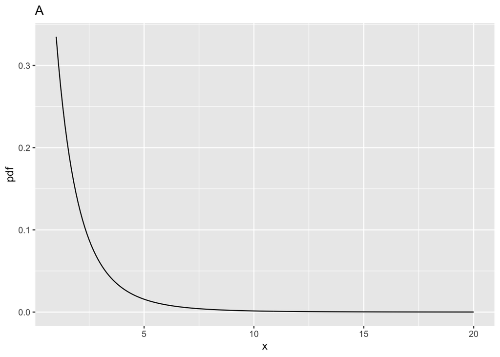

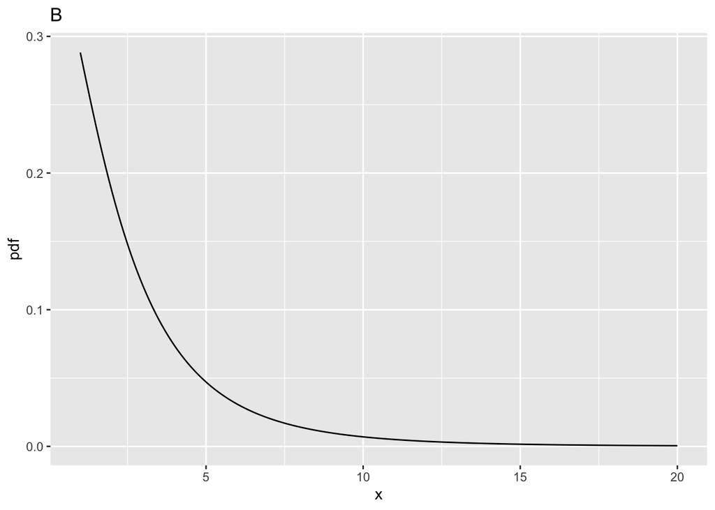

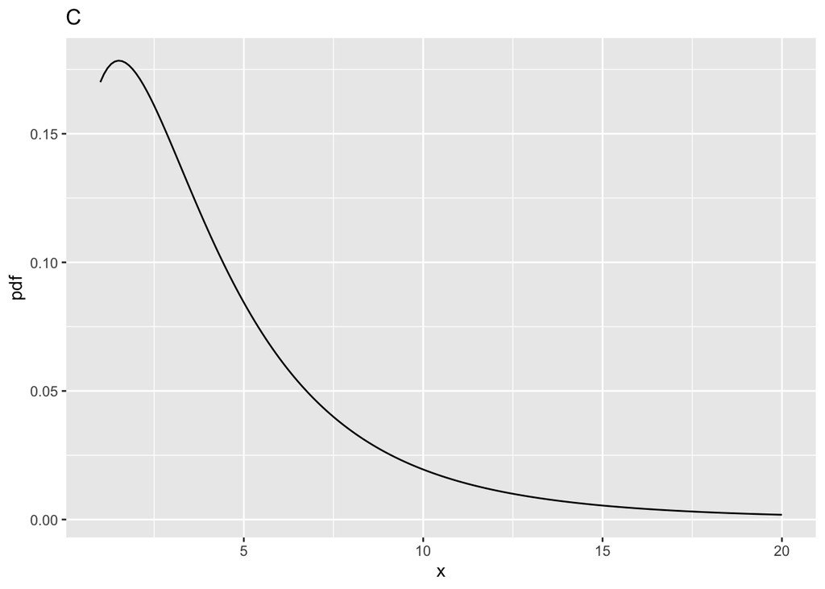

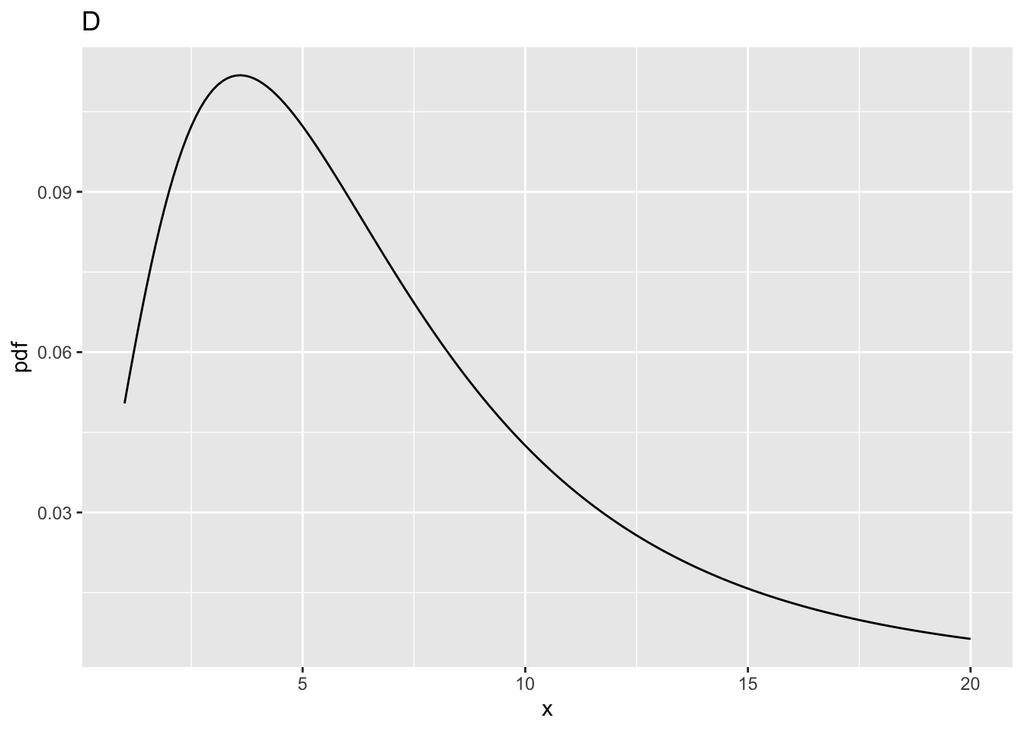

|  | ndf | ddf | fCrit | ncp | pFgtFCrit |
| --- | --- | --- | --- | --- | --- |
| A | 2 | 10 | 4.102821 | 0 | 0.0500000 |
| B | 2 | 10 | 4.102821 | 2 | 0.1775840 |
| C | 2 | 10 | 4.102821 | 5 | 0.3876841 |
| D | 2 | 10 | 4.102821 | 10 | 0.6769776 |

```r
ndf <- 2;ddf <- 10;ncp <- c(0,2,5,10)
alpha <- 0.05
fCrit <- qf(1-alpha, ndf,ddf)
x <- seq(1, 20, 0.1)
myLabel <- c("A", "B", "C", "D")
myLabelIndx <- 1
pFgtFCrit <- NULL
for (i in 1:length(ncp))
{
  y <- df(x,ndf,ddf,ncp=ncp[i])
  pFgtFCrit <- c(pFgtFCrit, 1-pf(fCrit, ndf, ddf, ncp = ncp[i]))
}
for (i in 1:length(ncp))
{
  y <- df(x,ndf,ddf,ncp=ncp[i])
  curveData <- data.frame(x = x, pdf = y)
  curvePlot <- ggplot(data = curveData, mapping = aes(x = x, y = pdf)) +
    geom_line() +
    ggtitle(myLabel[myLabelIndx]);myLabelIndx <- myLabelIndx + 1
  print(curvePlot)
}
fCrit_2_10 <- fCrit # convention fCrit_ndf_ddf
```

## Comments

### Fig. A

- This corresponds to `ncp = 0`, i.e., the *central* F-distribution.
- The integral under this distribution is unity (this is also true for all plots in this vignette).
- The critical value, `fCrit` in the above code block, is the value of `x` such that the probability of exceeding `x` is $\alpha$. The corresponding parameter `alpha` is defined above as 0.05.
- In the current example `fCrit` = 4.102821. Notice the use of the quantile function `qf()` to determine this value, and the default value of `ncp`, namely zero, is used; specifically, one does not pass a 4th argument to `qf()`.
- **The decision rule for rejecting the NH uses the NH distribution of the F-statistic**, i.e., reject the NH if F >= `fCrit`. As expected, `prob > fCrit` = 0.05 because this is how `fCrit` was defined.

### Fig. B

- This corresponds to `ncp = 2`, `ndf` = 2 and `ddf` = 10.
- The distribution is slightly shifted to the right as compared to Fig. A, thereby making it more likely that the observed value of the F-statistic will exceed the critical value determined for the NH distribution.
- In fact, `prob > fCrit` = 0.177584, i.e., the *statistical power* (compare this to Fig. A where `prob > fCrit` was 0.05).

### Fig. C

- This corresponds to `ncp = 5`, `ndf` = 2 and `ddf` = 10.
- Now `prob > fCrit` = 0.3876841.
- Power has increased compared to Fig. B.

### Fig. D

- This corresponds to `ncp = 10`, `ndf` = 2 and `ddf` = 10.
- Now `prob > fCrit` is 0.6769776.
- Power has increased compared to Fig. C.
- The effect of the shift is most obvious in Fig. C and Fig. D.
- Considering a vertical line at `x` = 4.102821, fraction 0.6769776 of the probability distribution in Fig. D lies to the right of this line
- Therefore the NH is likely to be rejected with probability 0.6769776.

### Summary

The larger that non-centrality parameter, the greater the shift to the right of the F-distribution, and the greater the statistical power.

## Effect of `ncp` for `ndf` = 2 and `ddf` = 100

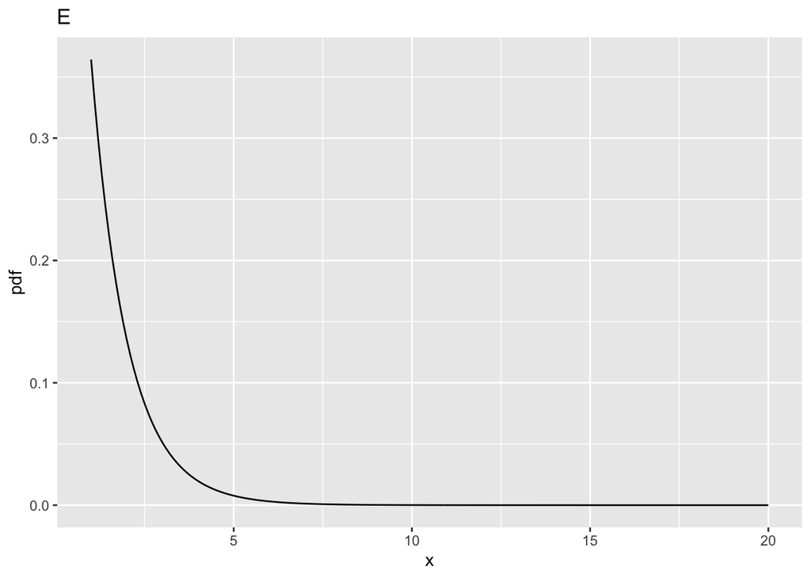

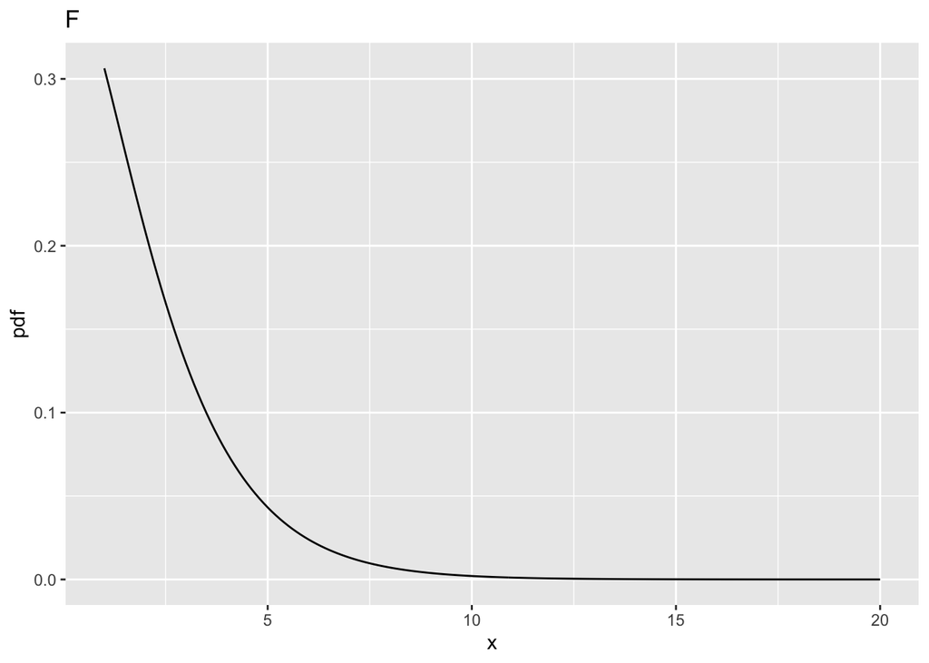

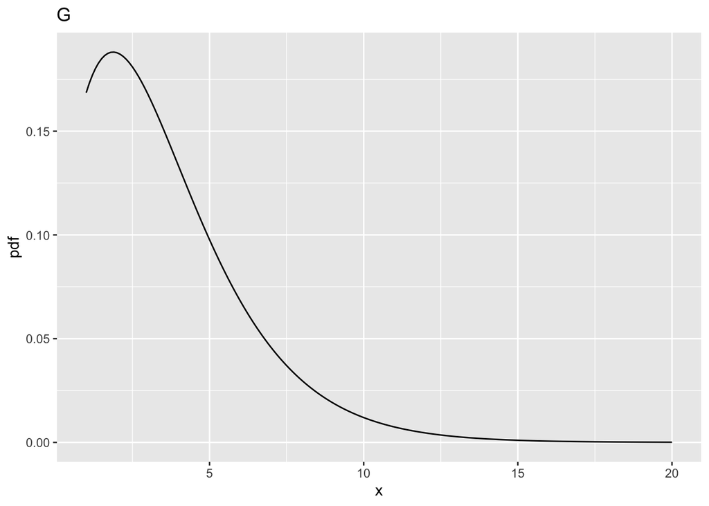

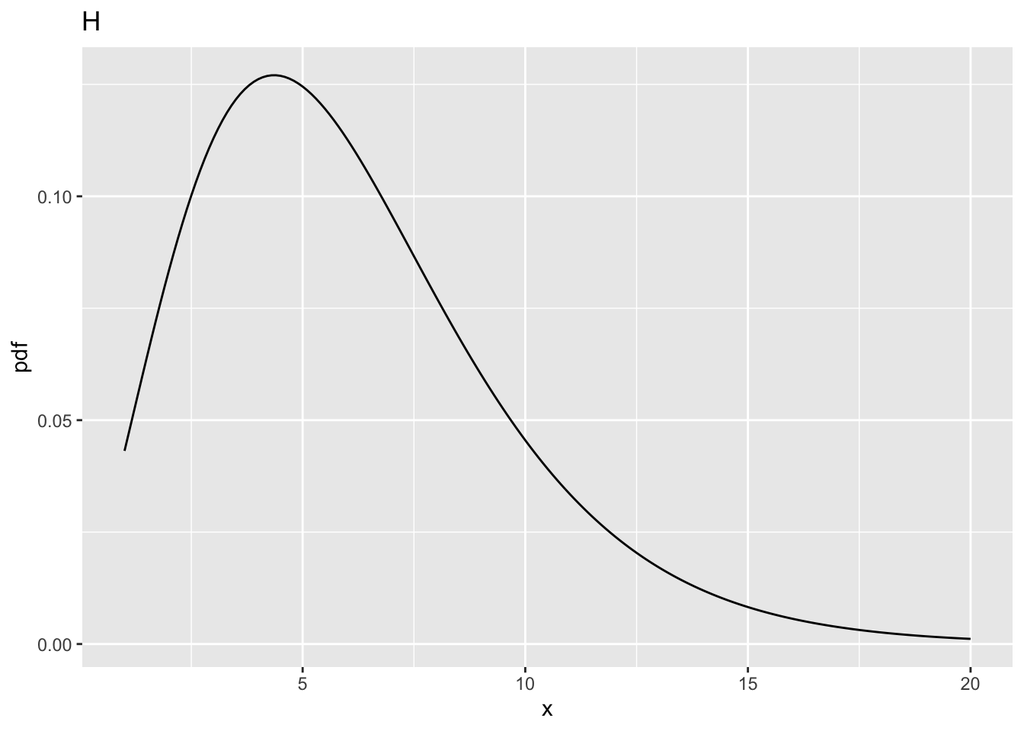

|  | ndf | ddf | fCrit | ncp | pFgtFCrit |
| --- | --- | --- | --- | --- | --- |
| A | 2 | 10 | 4.102821 | 0 | 0.0500000 |
| B | 2 | 10 | 4.102821 | 2 | 0.1775840 |
| C | 2 | 10 | 4.102821 | 5 | 0.3876841 |
| D | 2 | 10 | 4.102821 | 10 | 0.6769776 |
| E | 2 | 100 | 3.087296 | 0 | 0.0500000 |
| F | 2 | 100 | 3.087296 | 2 | 0.2199264 |
| G | 2 | 100 | 3.087296 | 5 | 0.4910802 |
| H | 2 | 100 | 3.087296 | 10 | 0.8029764 |

## Comments

- All comparisons in this sections are at the same values of `ncp` defined above.
- And between `ddf` = 100 and `ddf` = 10.

### Fig. E

- This corresponds to `ncp` = 0, `ndf` = 2 and `ddf` = 100.
- The critical value is `fCrit_2_100` = 3.0872959. Notice the decrease compared to the previous value for `ncp` = 0, i.e., 4.102821, for `ddf` = 10.
- One expects that increasing `ddf` will make it more likely that the NH will be rejected, and this is confirmed below.
- All else equal, statistical power increases with increasing `ddf`.

### Fig. F

- This corresponds to `ncp` = 2, `ndf` = 2 and `ddf` = 100.
- The probability of exceeding the critical value is `prob > fCrit_2_100` = 0.2199264, greater than the previous value, i.e., 0.177584 for `ddf` = 10.

### Fig. G

- This corresponds to `ncp = 5`, `ndf` = 2 and `ddf` = 100.
- The probability of exceeding the critical value is `prob > fCrit_2_100` = 0.4910802.
- This is greater than the previous value, i.e., 0.3876841 for `ddf` = 10.

### Fig. H

- This corresponds to `ncp = 10`, `ndf` = 2 and `ddf` = 100.
- The probability of exceeding the critical value is `prob > fCrit_2_100` is 0.8029764.
- This is greater than the previous value, i.e., 0.6769776 for `ddf` = 10.

## Effect of `ncp` for `ndf` = 1, `ddf` = 100

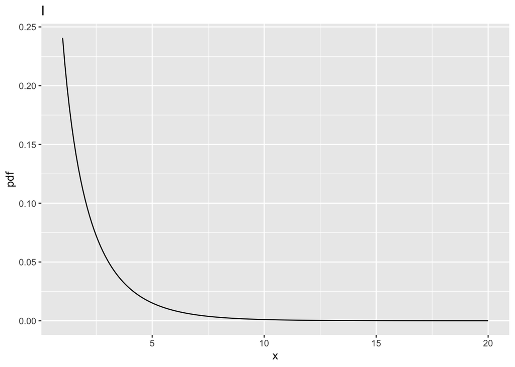

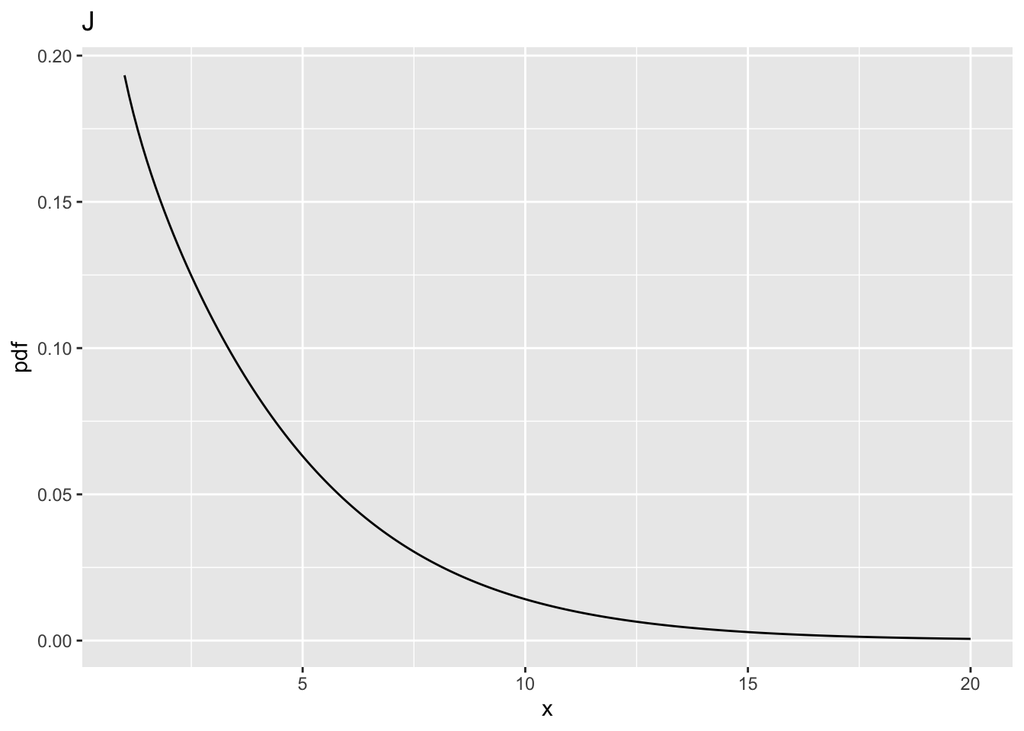

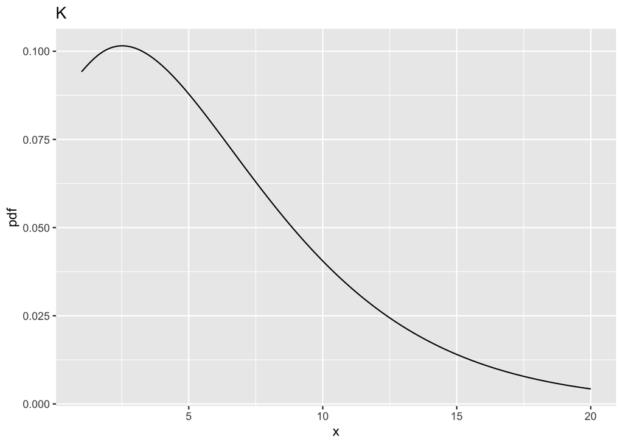

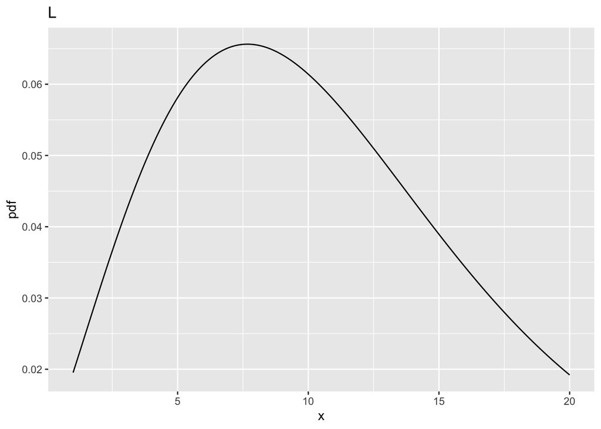

|  | ndf | ddf | fCrit | ncp | pFgtFCrit |
| --- | --- | --- | --- | --- | --- |
| A | 2 | 10 | 4.102821 | 0 | 0.0500000 |
| B | 2 | 10 | 4.102821 | 2 | 0.1775840 |
| C | 2 | 10 | 4.102821 | 5 | 0.3876841 |
| D | 2 | 10 | 4.102821 | 10 | 0.6769776 |
| E | 2 | 100 | 3.087296 | 0 | 0.0500000 |
| F | 2 | 100 | 3.087296 | 2 | 0.2199264 |
| G | 2 | 100 | 3.087296 | 5 | 0.4910802 |
| H | 2 | 100 | 3.087296 | 10 | 0.8029764 |
| I | 1 | 100 | 3.936143 | 0 | 0.0500000 |
| J | 1 | 100 | 3.936143 | 2 | 0.2883607 |
| K | 1 | 100 | 3.936143 | 5 | 0.6004962 |
| L | 1 | 100 | 3.936143 | 10 | 0.8793619 |

## Comments

- All comparisons in this sections are at the same values of `ncp` defined above and at `ddf` = 100.
- And between `ndf` = 1 and `ndf` = 2.

### Fig. I

- This corresponds to `ncp` = 0, `ndf` = 1 and `ddf` = 100.
- The critical value is `fCrit_1_100` = 3.936143.
- Notice the increase in the critical value as compared to the corresponding value for `ndf = 2`, i.e., 3.0872959.
- One might expect power to decrease, **but see below**.

### Fig. J

- This corresponds to `ncp` = 2, `ndf` = 1 and `ddf` = 100.
- Now `prob > fCrit_1_100` = 0.2883607, larger than the previous value 0.2199264.
- The power has actually increased.

### Fig. K

- This corresponds to `ncp` = 5, `ndf` = 1 and `ddf` = 100`’,
- Now `prob > fCrit_1_100` = 0.6004962, larger than the previous value 0.4910802.
- Again, the power has actually increased.

### Fig. L

- This corresponds to `ncp` = 10, `ndf` = 1 and `ddf` = 100
- Now `prob > fCrit_1_100` is 0.8793619, larger than the previous value 0.8029764.
- The power has actually increased.

## Summary

- Power increases with increasing `ddf` and `ncp`.
- The effect of increasing `ncp` is quite dramatic. This is because power depends on the square of `ncp`.
- Decreasing `ndf` also **increases** power. At first glance this may seem counterintuitive, as `fCrit` has gone up, but is explained by the differing shapes of the two distributions: the pdf is broader for `ndf` = 1 as compared to `ndf` = 2 (compare Fig. L to H).

## References

Chakraborty, Dev P. 2017. *Observer Performance Methods for Diagnostic Imaging - Foundations, Modeling, and Applications with R-Based Examples*. Book. Boca Raton, FL: CRC Press.